# Disciplina - DQF10648 Eletromagnetismo I

## Aula em 20/11/2020 - Semestre 2020/1 EARTE

### [DQF - CCENS](http://alegre.ufes.br/ccens/departamento-de-quimica-e-fisica) - [UFES/Alegre](http://alegre.ufes.br/)

# Exercícios ao vivo sobre operadores diferenciais vetoriais

### Exercícios sobre aplicação prática dos operadores diferenciais vetoriais gradiente, divergente, rotacional e laplaciano

## Gradiente : $\vec{\nabla} f$

### Revisão

Gradiente é um operador diferencial vetorial que atua sobre função escalar e gera função vetorial.

Operador diferencial vetorial gradiente (grad) em coordenadas cartesianas 2D $(x, y)$ :

$$\vec{\nabla} = \left\langle \frac{\partial}{\partial x}, \frac{\partial}{\partial y}\right\rangle = \frac{\partial}{\partial x}\hat{i} + \frac{\partial}{\partial y}\hat{j} $$

em coordenadas polares $(\rho, \theta)$ :

$$\vec{\nabla} = \left\langle \frac{\partial }{\partial \rho},\frac{1}{\rho}\frac{\partial }{\partial \theta }\right\rangle = \frac{\partial }{\partial \rho}\hat{\rho} + \frac{1}{\rho}\frac{\partial }{\partial \theta }\hat{\theta}$$

em coordenadas cartesianas 3D $(x, y, z)$ :

$$\vec{\nabla}=\left\langle \frac{\partial }{\partial x}, \frac{\partial }{\partial y}, \frac{\partial }{\partial z}\right\rangle = \frac{\partial}{\partial x}\hat{i} + \frac{\partial}{\partial y}\hat{j} + \frac{\partial}{\partial z}\hat{k}$$

Em coordenadas cilíndricas $(\rho, \theta, z)$ :

$$\vec{\nabla}=\left\langle \frac{\partial }{\partial \rho},\frac{1}{\rho}\frac{\partial }{\partial \theta},\frac{\partial }{\partial z}\right\rangle = \frac{\partial }{\partial \rho}\hat{\rho} + \frac{1}{\rho}\frac{\partial }{\partial \theta }\hat{\theta} + \frac{\partial }{\partial z}\hat{k} $$

Em coordenadas esféricas $(r, \theta, \phi)$ :

$$\vec{\nabla}=\left\langle \frac{\partial }{\partial r},\frac{1}{r}\frac{\partial }{\partial \theta},\frac{1}{r sen \theta}\frac{\partial }{\partial \phi}\right\rangle = \frac{\partial }{\partial r}\hat{r} + \frac{1}{r}\frac{\partial }{\partial \theta}\hat{\theta} + \frac{1}{r sen \theta}\frac{\partial }{\partial \phi}\hat{\phi}$$

Funções escalares comuns no Eletromagnetismo, etc :

1) Potencial elétrico de uma carga elétrica :

$$V(r)=\frac{q}{4\,\pi \,\epsilon _{0}\,r}$$

2) Função genérica : $$V(r)=\frac{1}{r^{2}}$$

3) Potencial elétrico de um dipolo elétrico :

$$V(r,\theta )=\frac{p\,\cos \theta }{4\,\pi \,\epsilon _{0}\,r^{2}}$$

4) Potencial elétrico do átomo de Rutherford :

$$V(r)=\frac{Z\ e}{4\,\pi \,\epsilon _{0}\,}\left( \frac{1}{r}-\frac{3}{2R}+% \frac{r^{2}}{2R^{3}}\right)$$

### 1) [Exercícios ao vivo propostos aos alunos] Calcule gradiente :

1.a) do potencial (1) em coordenadas cartesianas 3D e em coordenadas esféricas;

1.b) do potencial (2) em coordenadas cartesianas 3D, coordenadas cilíndricas e em coordenadas esféricas;

1.c) do potencial (3) em coordenadas cartesianas 2D e em coordenadas polares;

1.d) do potencial (4) em em coordenadas cartesianas 3D e em coordenadas esféricas;

Cálculo de (1.a) em coordenadas esféricas, feito rapidamente pelo professor em 17/11/2020 usando o software Xournal++ para Linux, onde se vê que se pode usar desenhos (feitos com o mouse), texto e expressões LaTeX :

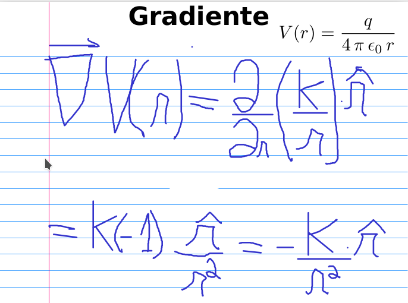

Os alunos não se voluntariaram e não fizeram nenhum dos exercícios ao vivo propostos.

## Divergente : $\vec{\nabla} \cdot \vec{F}$

### Revisão

Divergente é um operador diferencial vetorial que atua sobre função função e gera função escalar.

Em coordenadas cartesianas 3D $(x, y, z)$ :

$$\vec{\nabla} \cdot \vec{F} = \frac{\partial F_x}{\partial x} + \frac{\partial F_y}{\partial y} + \frac{\partial F_z}{\partial z} $$

em coordenadas cilíndricas $(\rho, \theta, z)$ :

$$\vec{\nabla} \cdot \vec{F} = \frac{1}{\rho}\frac{\partial (\rho F_{\rho})}{\partial \rho} + \frac{1}{\rho}\frac{\partial F_{\theta}}{\partial \theta} + \frac{\partial F_z}{\partial z} $$

em coordenadas esféricas $(r, \theta, \phi)$ :

$$\vec{\nabla} \cdot \vec{F} = \frac{1}{r^2} \frac{\partial (r^2 F_r)}{\partial r} + \frac{1}{r sen \theta}\frac{\partial (sen \theta F_{\theta})}{\partial \theta} + \frac{1}{r sen \theta}\frac{\partial F_\phi}{\partial \phi} $$

### 1) [Exercícios ao vivo propostos aos alunos] Calcule divergente :

1.a) Calcule o divergente em coordenadas esféricas, coordenadas cartesianas 3D e coordenadas cilíndricas. Ao final o resultado deve ser o mesmo, verifique. Sugestão, primeiro escreva a função vetorial (no caso o vetor posição $\vec{r}$) no sistema de coordenadas respectivo :

$$\vec{\nabla} \cdot \vec{r}$$

Resolução de (1.a) em coordenadas esféricas :

$$\vec{r} = r \hat{r} = \vec{F} = F_r \hat{r} $$$$\vec{\nabla} \cdot \vec{F} = \frac{1}{r^2} \frac{\partial (r^2 F_r)}{\partial r} + \frac{1}{r sen \theta}\frac{\partial (sen \theta F_{\theta})}{\partial \theta} + \frac{1}{r sen \theta}\frac{\partial F_\phi}{\partial \phi} $$$$\vec{\nabla} \cdot (r \hat{r}) = \frac{1}{r^2} \frac{\partial (r^2 r)}{\partial r} = 3 $$

1.b) Calcule o divergente em coordenadas esféricas e coordenadas cilíndricas. Ao final o resultado deve ser o mesmo, verifique. Sugestão, primeiro escreva a função vetorial no sistema de coordenadas respectivo :

$$\vec{\nabla} \cdot \left( \frac{\hat{r}}{r} \right)$$

1.c) Calcule o divergente em coordenadas esféricas. Sem e com delta de Dirac :

$$\vec{\nabla} \cdot \left( \frac{\hat{r}}{r^2} \right)$$